# Homework 5 Solutions

## Question 1

```r
bryozoan_larvae_early <- bryozoan %>%
  filter(Stage != "late") %>%
  mutate(log_mass = log(Mass),
         log_metabolic = log(Metabolic))
```

## Question 2

Based on the scatterplot, model 4 is the most appropriate. From the scatterplot, we can see that the vertical distance between the early and larval stages is different for the bugula and watersipora. This can only happen if there is an interaction between species and stage (the interaction allows more flexibility in the intercepts).

## Question 3

```r
ble_lm <- lm(log_metabolic ~ Species*Stage + log_mass,
             data = bryozoan_larvae_early)
summary(ble_lm)
```

```
##
## Call:
## lm(formula = log_metabolic ~ Species * Stage + log_mass, data = bryozoan_larvae_early)
##
## Residuals:
##      Min       1Q   Median       3Q      Max
## -1.73890 -0.22376  0.03333  0.25679  0.93404
##
## Coefficients:
##                                Estimate Std. Error t value Pr(>|t|)
## (Intercept)                    -3.33814    0.19379 -17.226  < 2e-16 ***
## Specieswatersipora              0.47404    0.05586   8.486  < 2e-16 ***
## Stagelarvae                     1.42257    0.04030  35.302  < 2e-16 ***
## log_mass                        0.57672    0.07299   7.901 1.46e-14 ***
## Specieswatersipora:Stagelarvae -0.79056    0.06745 -11.721  < 2e-16 ***
## ---
## Signif. codes:  0 '***' 0.001 '**' 0.01 '*' 0.05 '.' 0.1 ' ' 1
##
## Residual standard error: 0.3592 on 563 degrees of freedom
## Multiple R-squared:  0.7675, Adjusted R-squared:  0.7659
## F-statistic: 464.8 on 4 and 563 DF,  p-value: < 2.2e-16
```

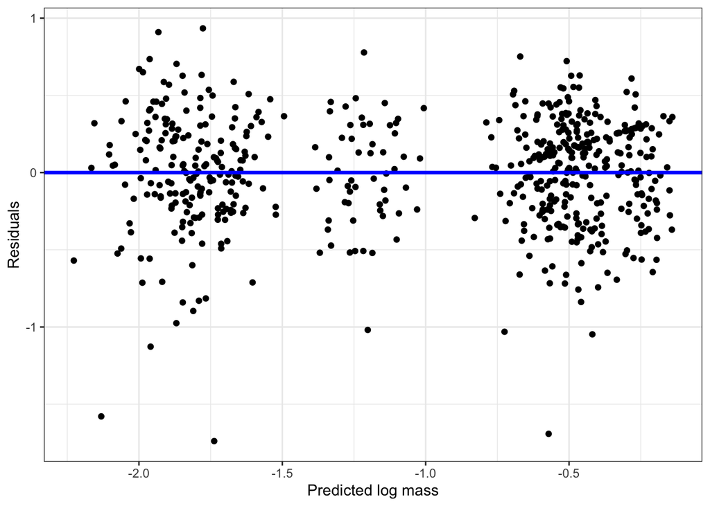

```r
bryozoan_larvae_early %>%
  mutate(pred = predict(ble_lm),
         res = residuals(ble_lm)) %>%
  ggplot(aes(x = pred, y = res)) +
  geom_point() +
  geom_abline(slope = 0, intercept = 0,
              color = "blue", lwd = 1.2) +
  labs(x = "Predicted log mass",
       y = "Residuals") +
  theme_bw()
```

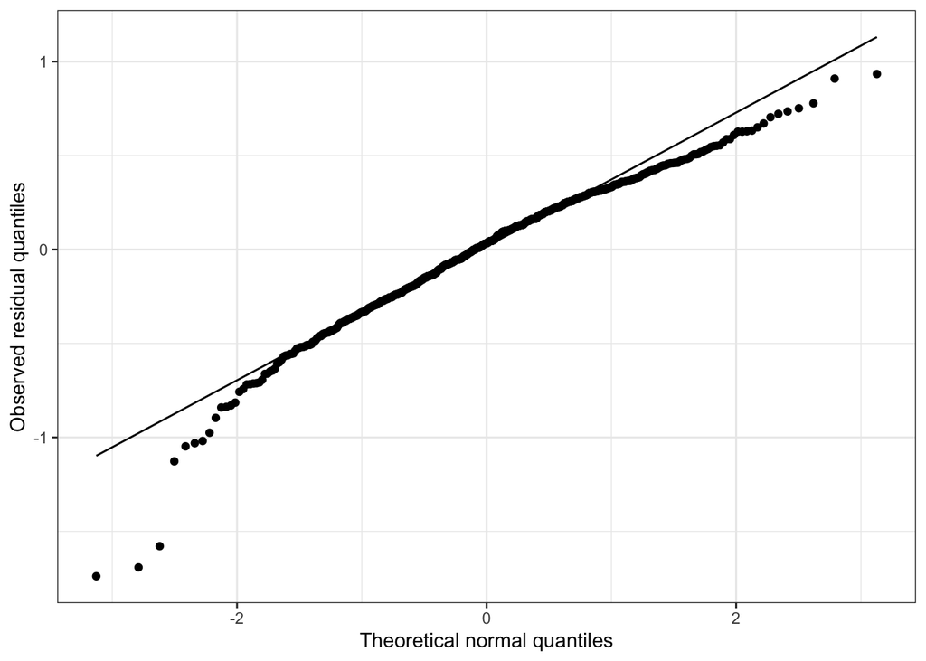

```r
bryozoan_larvae_early %>%
  mutate(res = residuals(ble_lm)) %>%
  ggplot(aes(sample = res)) +
  geom_qq() +
  geom_qq_line() +
  labs(x = "Theoretical normal quantiles",
       y = "Observed residual quantiles") +
  theme_bw()
```

The equation of the fitted regression line is

$\widehat{\log(\text{metabolic rate})} = -3.34 + 0.47 \text{IsWatersipora} + 1.42 \text{IsLarval} - 0.79 \text{IsWatersipora} \cdot \text{IsLarval} + 0.58 \log(\text{mass})$

Based on the residual plot, the shape and constant variance assumptions both look reasonable. (Students may say that shape or constant variance doesn’t look reasonable because we have clusters of points; however, these are only clusters along the x-axis (the residuals are still scattered randomly in the y direction), and they result from having different intercepts for different groups).

Based on the qq plot, the normality assumption looks pretty good, with the exception of a few points in the left tail which deviate substantially. And with 568 points in the data, and a pretty small model, we’re not that worried about the normality assumption.

## Question 4

```r
# test statistic
(0.57672 - 1)/0.073
```

```
## [1] -5.798356
```

```r
# p-value
pt(-5.80, 563, lower.tail = T)
```

```
## [1] 5.532774e-09
```

Our hypotheses are $H_0: \beta_4 = 1$ and $H_A: \beta_4 < 1$. Our test statistic is $t = -5.80$, and the corresponding p-value is $5.53 \times 10^{-9}$. Note that the degrees of freedom for calculating the p-value are 563 (= $n-p$). Since the p-value is very close to 0, we have strong evidence that larger organisms are more energy efficient, proportional to body size.

## Question 5

```r
ble_lm_full <- lm(log_metabolic ~ Species*Stage*log_mass,
                  data = bryozoan_larvae_early)

anova(ble_lm, ble_lm_full)
```

```
## Analysis of Variance Table
##
## Model 1: log_metabolic ~ Species * Stage + log_mass
## Model 2: log_metabolic ~ Species * Stage * log_mass
##   Res.Df    RSS Df Sum of Sq      F Pr(>F)
## 1    563 72.646
## 2    560 72.635  3  0.011532 0.0296 0.9931
```

To test whether there is any difference in slope across the different species or stages, we need to allow the slope to vary across species and stages. This involves adding interaction terms, and our full model is

$\log(\text{metabolic rate}) = \beta_0 + \beta_1 \text{IsWatersipora} + \beta_2 \text{IsLarval} + \beta_3 \text{IsWatersipora} \cdot \text{IsLarval} + \beta_4 \log(\text{mass}) +$

$\hspace{4cm} \beta_5 \text{IsWatersipora} \cdot \log(\text{mass}) + \beta_6 \text{IsLarval} \cdot \log(\text{mass}) +$

$\hspace{4cm} \beta_7 \text{IsWatersipora} \cdot \text{IsLarval} \cdot \log(\text{mass}) + \varepsilon$

Our reduced model is model (4) from the assignment, which we fit above.

Our test statistic is $F = 0.0296$, and the associated p-value is 0.993. This p-value is very close to 1, so there is very little evidence that the slope is different across species or stages.

## Question 6

```r
mlb_new <- MLBStandings2016 %>%
  select(-c(Wins, Losses, Team))
```

## Question 7

```r
model_1 <- lm(WinPct ~ League + BattingAverage + Runs +
                Hits + HR + Doubles + Triples +
                RBI + SB + OBP +
                ERA + HitsAllowed + Walks +
                StrikeOuts + Saves + WHIP,
              data = mlb_new)

model_2 <- lm(WinPct ~ League + BattingAverage + Runs +
                Hits + HR + Doubles + Triples +
                RBI + SB + OBP + SLG +
                ERA + HitsAllowed + Walks +
                StrikeOuts + Saves + WHIP,
              data = mlb_new)
```

Many examples are possible. Here’s one: fit a model with all the predictors except SLG. Then $R^2_{adj} = 0.899$. If we add SLG to the model, $R^2_{adj}$ decreases to 0.894.

## Question 8

```r
# maximizing adjusted R2:
models <- regsubsets(WinPct ~ ., data = mlb_new,
                     nvmax = 17)

optimal_model_size <- which.max(summary(models)$adjr2)
summary(models)$which[optimal_model_size,]
```

```
##    (Intercept)       LeagueNL BattingAverage           Runs           Hits
##           TRUE          FALSE           TRUE           TRUE           TRUE
##             HR        Doubles        Triples            RBI             SB
##          FALSE           TRUE          FALSE          FALSE          FALSE
##            OBP            SLG            ERA    HitsAllowed          Walks
##           TRUE          FALSE           TRUE           TRUE           TRUE
##     StrikeOuts          Saves           WHIP
##          FALSE           TRUE           TRUE
```

```r
# minimizing Mallows' Cp:
optimal_model_size <- which.min(summary(models)$cp)
summary(models)$which[optimal_model_size,]
```

```
##    (Intercept)       LeagueNL BattingAverage           Runs           Hits
##           TRUE          FALSE           TRUE           TRUE           TRUE
##             HR        Doubles        Triples            RBI             SB
##          FALSE          FALSE          FALSE          FALSE          FALSE
##            OBP            SLG            ERA    HitsAllowed          Walks
##           TRUE          FALSE          FALSE           TRUE           TRUE
##     StrikeOuts          Saves           WHIP
##          FALSE           TRUE           TRUE
```

The model which maximizes $R^2_{adj}$ includes BattingAverage, Runs, Hits, Doubles, OBP, ERA, HitsAllowed, Walks, Saves, and WHIP.

The model which minimizes Mallows’ $C_p$ includes BattingAverage, Runs, Hits, OBP, HitsAllowed, Walks, Saves, and WHIP.

## Question 9

```r
best_model <- lm(WinPct ~ BattingAverage + Runs + Hits +
                   OBP + HitsAllowed + Walks + Saves + WHIP,
                 data = mlb_new)

vif(best_model)
```

```
## BattingAverage           Runs           Hits            OBP    HitsAllowed
##      52.914504       3.573938      43.532134       6.192419      88.628047
##          Walks          Saves           WHIP
##      25.358101       1.261219     148.311536
```

There is appears to be high multicollinearity, with high variance inflation factors for most of the predictors. This makes it challenging to interpret the fitted model, since we can’t really think about changing the value of one predictor while holding the other predictors fixed.